# sprint7

### Project description

Mobile carrier Megaline has found out that many of their subscribers use legacy plans. They want to develop a model that would analyze subscribers' behavior and recommend one of Megaline's newer plans: Smart or Ultra.

You have access to behavior data about subscribers who have already switched to the new plans (from the project for the Statistical Data Analysis course). For this classification task, you need to develop a model that will pick the right plan. Since you’ve already performed the data preprocessing step, you can move straight to creating the model.

Develop a model with the highest possible *accuracy*. In this project, the threshold for *accuracy* is 0.75. Check the *accuracy* using the test dataset.

### Data description

Every observation in the dataset contains monthly behavior information about one user. The information given is as follows:

- *сalls* — number of calls,
- *minutes* — total call duration in minutes,
- *messages* — number of text messages,
- *mb_used* — Internet traffic used in MB,
- *is_ultra* — plan for the current month (Ultra - 1, Smart - 0).

### Step 1.

Open and look through the data file. Path to the file:`datasets/users_behavior.csv`

```python
!pip install imblearn -q
```

```python
!pip install catboost -q
```

```python
import numpy as np
import pandas as pd
import matplotlib.pyplot as plt
import seaborn as sns
from scipy import stats
from sklearn.linear_model import LogisticRegression, LogisticRegressionCV
from sklearn.model_selection import train_test_split, GridSearchCV, cross_val_predict, RandomizedSearchCV, ParameterGrid
from sklearn.tree import DecisionTreeClassifier
from sklearn.dummy import DummyClassifier
from sklearn.ensemble import RandomForestClassifier, IsolationForest
from sklearn.neighbors import LocalOutlierFactor
from sklearn.preprocessing import StandardScaler
from sklearn.pipeline import make_pipeline, Pipeline
from sklearn.metrics import *
from imblearn.over_sampling import RandomOverSampler
from imblearn.under_sampling import RandomUnderSampler
from sklearn.naive_bayes import GaussianNB
from xgboost import XGBClassifier
from catboost import CatBoostClassifier
%matplotlib inline
import logging
logger = logging.getLogger()
logger.setLevel(logging.CRITICAL)
import warnings
warnings.filterwarnings("ignore")
from sklearn import set_config
set_config(print_changed_only=False)
```

```python
## global seed ##
import random
rnd_state = 42
np.random.seed(rnd_state)
random.seed(rnd_state)
```

```python
def display_classification_report(y_true, y_pred):
    display(pd.DataFrame(classification_report(y_test, y_pred, output_dict=True)).T)
```

```python
def plot_roc(y_test, preds, ax=None, label='model'):
    if not ax:
        fig, ax = plt.subplots(1, 1)
    fpr, tpr, thresholds = roc_curve(y_test, preds)
    ax.plot(fpr, tpr, lw=2, label=label)
    ax.legend(loc='lower right')
    ax.set_title('ROC curve')
    ax.set_xlabel('False Positive Rate (FPR)')
    ax.set_ylabel('True Positive Rate (TPR)')
    ax.annotate(f'AUC: {auc(fpr, tpr):.2}', xy=(.43, .025))
    return ax

def plot_pr(y_test, preds, ax=None, label='model'):
    precision, recall, thresholds = precision_recall_curve(y_test, preds)

    if not ax:
        fig, ax = plt.subplots()

    ax.plot(recall, precision, lw=2, label=label)

    ax.legend()
    ax.set_title(
        'Precision-recall curve\n'
        f""" AP: {average_precision_score(
            y_test, preds, pos_label=1
        ):.2} | """
        f'AUC: {auc(recall, precision):.2}'
    )
    ax.set_xlabel('Recall')
    ax.set_ylabel('Precision')

    ax.set_xlim(-0.05, 1.05)
    ax.set_ylim(-0.05, 1.05)

    return ax
```

```python
host="https://code.s3.yandex.net/"
```

```python
df = pd.read_csv(host+"datasets/users_behavior.csv")
```

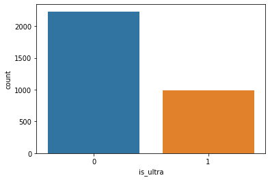

```python
sns.countplot(df["is_ultra"])
```

```python
df["is_ultra"].value_counts()/len(df)*100
```

```
0    69.352831
1    30.647169
Name: is_ultra, dtype: float64
```

```python
df.head()
```

|  | calls | minutes | messages | mb_used | is_ultra |
| --- | --- | --- | --- | --- | --- |
| 0 | 40.0 | 311.90 | 83.0 | 19915.42 | 0 |
| 1 | 85.0 | 516.75 | 56.0 | 22696.96 | 0 |
| 2 | 77.0 | 467.66 | 86.0 | 21060.45 | 0 |
| 3 | 106.0 | 745.53 | 81.0 | 8437.39 | 1 |
| 4 | 66.0 | 418.74 | 1.0 | 14502.75 | 0 |

```python
df.describe()
```

|  | calls | minutes | messages | mb_used | is_ultra |
| --- | --- | --- | --- | --- | --- |
| count | 3214.000000 | 3214.000000 | 3214.000000 | 3214.000000 | 3214.000000 |
| mean | 63.038892 | 438.208787 | 38.281269 | 17207.673836 | 0.306472 |
| std | 33.236368 | 234.569872 | 36.148326 | 7570.968246 | 0.461100 |
| min | 0.000000 | 0.000000 | 0.000000 | 0.000000 | 0.000000 |
| 25% | 40.000000 | 274.575000 | 9.000000 | 12491.902500 | 0.000000 |
| 50% | 62.000000 | 430.600000 | 30.000000 | 16943.235000 | 0.000000 |
| 75% | 82.000000 | 571.927500 | 57.000000 | 21424.700000 | 1.000000 |
| max | 244.000000 | 1632.060000 | 224.000000 | 49745.730000 | 1.000000 |

```python
df.info()
```

```
<class 'pandas.core.frame.DataFrame'>
RangeIndex: 3214 entries, 0 to 3213
Data columns (total 5 columns):
 #   Column    Non-Null Count  Dtype
---  ------    --------------  -----
 0   calls     3214 non-null   float64
 1   minutes   3214 non-null   float64
 2   messages  3214 non-null   float64
 3   mb_used   3214 non-null   float64
 4   is_ultra  3214 non-null   int64
dtypes: float64(4), int64(1)
memory usage: 125.7 KB
```

```python
target = "is_ultra"
features = ["calls", "minutes", "messages", "mb_used"]
```

```python
#missing value ratio
def missing_values(df):
    df_nulls=pd.concat([df.dtypes, df.isna().sum(), df.isna().sum()/len(df)], axis=1)
    df_nulls.columns = ["type","count","missing_ratio"]
    df_nulls=df_nulls[df_nulls["count"]>0]
    df_nulls.sort_values(by="missing_ratio", ascending=False)
    return df_nulls

#outliers by 3 sigma rule
def outlier(data):
    data_mean, data_std = np.mean(data), np.std(data)
    cut_off = data_std * 3
    lower, upper = data_mean - cut_off, data_mean + cut_off
    outliers = [x for x in data if x < lower or x > upper]
    outliers_removed = [x for x in data if x >= lower and x <= upper]
    return len(outliers)

# full description statistics
def describe_full(df, target_name=""):
    data_describe = df.describe().T
    df_numeric = df._get_numeric_data()
    if target_name in df.columns:
        corr_with_target=df_numeric.drop(target_name, axis=1).apply(lambda x: x.corr(df_numeric[target_name]))
        data_describe['corr_with_target']=corr_with_target
    dtype_df = df_numeric.dtypes
    data_describe['dtypes'] = dtype_df
    data_null = df_numeric.isnull().sum()/len(df) * 100
    data_describe['Missing %'] = data_null
    Cardinality = df_numeric.apply(pd.Series.nunique)
    data_describe['Cardinality'] = Cardinality
    df_skew = df_numeric.skew(axis=0, skipna=True)
    data_describe['Skew'] = df_skew
    data_describe['outliers']=[outlier(df_numeric[col]) for col in df_numeric.columns]
    data_describe['kurtosis']=df_numeric.kurtosis()
    return data_describe
```

```python
describe_full(df, target)
```

|  | count | mean | std | min | 25% | 50% | 75% | max | corr_with_target | dtypes | Missing % | Cardinality | Skew | outliers | kurtosis |
| --- | --- | --- | --- | --- | --- | --- | --- | --- | --- | --- | --- | --- | --- | --- | --- |
| calls | 3214.0 | 63.038892 | 33.236368 | 0.0 | 40.0000 | 62.000 | 82.0000 | 244.00 | 0.207122 | float64 | 0.0 | 184 | 0.606372 | 34 | 1.028164 |
| minutes | 3214.0 | 438.208787 | 234.569872 | 0.0 | 274.5750 | 430.600 | 571.9275 | 1632.06 | 0.206955 | float64 | 0.0 | 3142 | 0.607851 | 34 | 0.927967 |
| messages | 3214.0 | 38.281269 | 36.148326 | 0.0 | 9.0000 | 30.000 | 57.0000 | 224.00 | 0.203830 | float64 | 0.0 | 180 | 1.295765 | 46 | 1.999601 |
| mb_used | 3214.0 | 17207.673836 | 7570.968246 | 0.0 | 12491.9025 | 16943.235 | 21424.7000 | 49745.73 | 0.198568 | float64 | 0.0 | 3203 | 0.430091 | 26 | 0.822764 |
| is_ultra | 3214.0 | 0.306472 | 0.461100 | 0.0 | 0.0000 | 0.000 | 1.0000 | 1.00 | NaN | int64 | 0.0 | 2 | 0.839943 | 0 | -1.295302 |

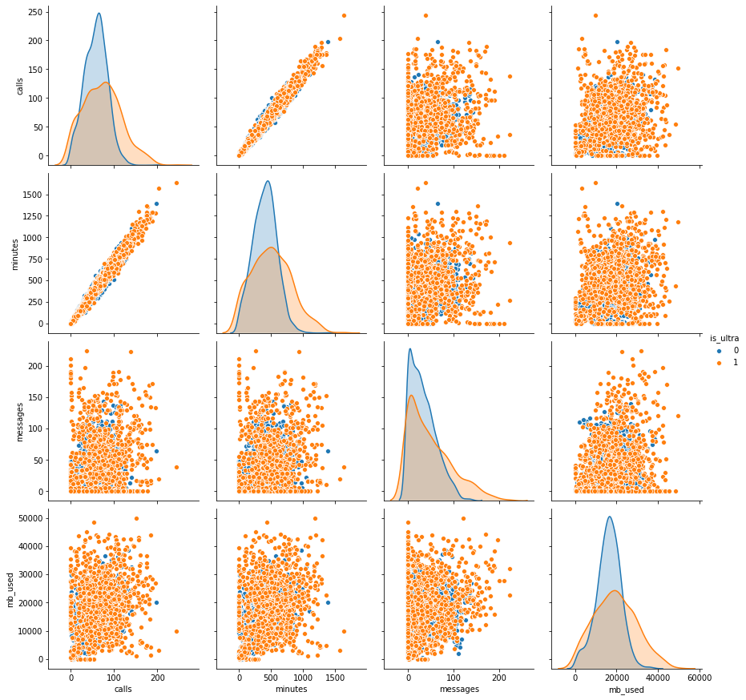

```python
sns.pairplot(df, hue=target, size=3)
```

### Step 2.

Split the source data into a training set, a validation set, and a test set.

```python
X, y = df[features], df[target]
X_train, X_test, y_train, y_test = train_test_split(X, y, test_size=0.2,\
                                                    random_state=rnd_state, stratify = y)

X_train, X_val, y_train, y_val \
    = train_test_split(X_train, y_train, test_size=0.25, random_state=rnd_state)
```

Let's check the validity of our split:

```python
X_train.shape, X_test.shape
```

```
((1928, 4), (643, 4))
```

```python
set(X_train.index) & set(X_test.index)
```

```
set()
```

```python
set(X_val.index) & set(X_test.index)
```

```
set()
```

```python
print(f"train = {100*len(X_train)/len(df):.4f}%")
print(f"val = {100*len(X_val)/len(df):.4f}%")
print(f"test = {100*len(X_test)/len(df):.4f}%")
```

```
train = 59.9876%
val = 20.0062%
test = 20.0062%
```

```python
X_train, X_val, X_test, y_train, y_val, y_test = \
            X_train.values, X_val.values, X_test.values, y_train.values, y_val.values, y_test.values
```

Let's see most important features

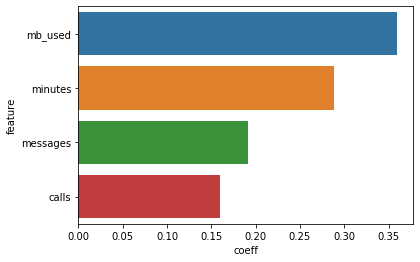

```python
rfc = DecisionTreeClassifier().fit(X_train, y_train)
y_pred = rfc.predict(X_test)
df_feature_importances = pd.DataFrame(((zip(features, rfc.feature_importances_)))).rename(columns={0:"feature",1:"coeff"}).sort_values(by="coeff", ascending = False )
sns.barplot(data=df_feature_importances, x=df_feature_importances["coeff"], y=df_feature_importances["feature"])
```

features sorted by importance

```python
features = list(df_feature_importances["feature"])
features
```

```
['mb_used', 'minutes', 'messages', 'calls']
```

### Step 3, 4, 5

Investigate the quality of different models by changing hyperparameters. Briefly describe the findings of the study.

Check the quality of the model using the test set.

Additional task: sanity check the model. This data is more complex than what you’re used to working with, so it's not an easy task. We'll take a closer look at it later.

I did 3-5 tasks alltogether, and also used already implemented scikit classes of cross validation

### Baselines:

#### Dummy Classifier and Gaussian Naive Bayes

```python
dummy_model = DummyClassifier(strategy='stratified').fit(X_train, y_train)
dummy_preds = dummy_model.predict(X_test)
print(f"mean accuracy on test set: {dummy_model.score(X_test, y_test):.2f}")
```

```
mean accuracy on test set: 0.55
```

```python
nb_pipeline = Pipeline([
    ('scale', StandardScaler()),
    ('nb', GaussianNB())
]).fit(X_train, y_train)
nb_preds = nb_pipeline.predict(X_test)
print(f"porb of each classes: {nb_pipeline.named_steps['nb'].class_prior_}")
print(f"mean accuracy on test set: {nb_pipeline.named_steps['nb'].score(X_test, y_test):.2f}")
```

```
porb of each classes: [0.69346473 0.30653527]
mean accuracy on test set: 0.31
```

As we see random guessing baseline around 60%

#### LogisticRegression

```python
lr = LogisticRegression().fit(X_train, y_train)
y_pred = lr.predict(X_test)
print(accuracy_score(y_test, y_pred))
print(confusion_matrix(y_test, y_pred))
display_classification_report(y_test, y_pred)
```

```
0.7107309486780715
[[440   6]
 [180  17]]
```

|  | precision | recall | f1-score | support |
| --- | --- | --- | --- | --- |
| 0 | 0.709677 | 0.986547 | 0.825516 | 446.000000 |
| 1 | 0.739130 | 0.086294 | 0.154545 | 197.000000 |
| accuracy | 0.710731 | 0.710731 | 0.710731 | 0.710731 |
| macro avg | 0.724404 | 0.536421 | 0.490031 | 643.000000 |
| weighted avg | 0.718701 | 0.710731 | 0.619946 | 643.000000 |

```python
lr=LogisticRegression().fit(X_train, y_train)
y_pred = cross_val_predict(lr, X_test, y_test, cv=5)
print(accuracy_score(y_test, y_pred))
print(confusion_matrix(y_test, y_pred))
display_classification_report(y_test, y_pred)
```

```
0.7433903576982893
[[437   9]
 [156  41]]
```

|  | precision | recall | f1-score | support |
| --- | --- | --- | --- | --- |
| 0 | 0.736931 | 0.979821 | 0.841193 | 446.00000 |
| 1 | 0.820000 | 0.208122 | 0.331984 | 197.00000 |
| accuracy | 0.743390 | 0.743390 | 0.743390 | 0.74339 |
| macro avg | 0.778465 | 0.593971 | 0.586589 | 643.00000 |
| weighted avg | 0.762381 | 0.743390 | 0.685184 | 643.00000 |

#### hyper parameters tuning

```
0.744945567651633
[[439   7]
 [157  40]]
```

|  | precision | recall | f1-score | support |
| --- | --- | --- | --- | --- |
| 0 | 0.736577 | 0.984305 | 0.842610 | 446.000000 |
| 1 | 0.851064 | 0.203046 | 0.327869 | 197.000000 |
| accuracy | 0.744946 | 0.744946 | 0.744946 | 0.744946 |
| macro avg | 0.793821 | 0.593675 | 0.585240 | 643.000000 |
| weighted avg | 0.771653 | 0.744946 | 0.684906 | 643.000000 |

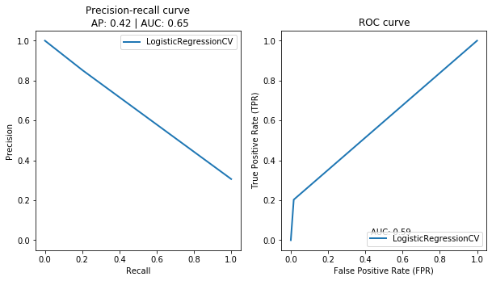

```python
lrcv = LogisticRegressionCV(
    Cs=[0.1,1,10], penalty='l2', tol=1e-10, scoring='neg_log_loss', cv=5,
    solver='liblinear', n_jobs=4, verbose=0, refit=True,
    max_iter=100,
).fit(X_train, y_train)
y_pred = lrcv.predict(X_test)
print(accuracy_score(y_test, y_pred))
print(confusion_matrix(y_test, y_pred))
display_classification_report(y_test, y_pred)

_, axs = plt.subplots(1, 2,figsize=(10,5))
axs = axs.ravel()
plot_pr(y_test, y_pred, ax=axs[0], label="LogisticRegressionCV")
plot_roc(y_test, y_pred, ax=axs[1], label="LogisticRegressionCV")
```

#### DecisionTreeClassifier

```python
dt = DecisionTreeClassifier().fit(X_train, y_train)
y_pred = dt.predict(X_test)
print(dt.score(X_train, y_train))
print(accuracy_score(y_test, y_pred))
print(confusion_matrix(y_test, y_pred))
display_classification_report(y_test, y_pred)
```

```
1.0
0.7309486780715396
[[363  83]
 [ 90 107]]
```

|  | precision | recall | f1-score | support |
| --- | --- | --- | --- | --- |
| 0 | 0.801325 | 0.813901 | 0.807564 | 446.000000 |
| 1 | 0.563158 | 0.543147 | 0.552972 | 197.000000 |
| accuracy | 0.730949 | 0.730949 | 0.730949 | 0.730949 |
| macro avg | 0.682241 | 0.678524 | 0.680268 | 643.000000 |
| weighted avg | 0.728356 | 0.730949 | 0.729563 | 643.000000 |

as we see by default DecisionTreeClassifier just memorized whole dataset and our model became overfitting

we could search hyper parameters by hand

```
diff        -0.001669
val_score    0.782271
Name: 0, dtype: float64
0.80248833592535
{'criterion': 'gini', 'max_depth': 8, 'min_samples_leaf': 6, 'min_samples_split': 16}
```

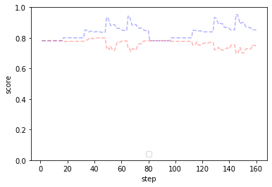

```python
train_scores = []
val_scores = []
steps = []
params_array = []

params = {
"criterion":["gini", "entropy"],
"max_depth":[2,4,8,16, 32],
"min_samples_split":[2,4,8, 16],
"min_samples_leaf":[2,4,6,8]}

for step, p in enumerate(ParameterGrid(params), start=1):
    dtc = DecisionTreeClassifier(**p).fit(X_train, y_train)
    train_scores.append(dtc.score(X_train, y_train))
    val_scores.append(dtc.score(X_val, y_val))
    steps.append(step)
    params_array.append(p)

train_scores = np.array(train_scores)
val_scores = np.array(val_scores)
plt.plot(steps, train_scores, color='blue', alpha=0.3, linestyle='dashed')
plt.plot(steps, val_scores, color='red', alpha=0.3, linestyle='dashed')
plt.legend(loc='lower center')
plt.ylim(0, 1)
plt.xlabel('step')
plt.ylabel('score')
scores_df = pd.DataFrame({"diff":train_scores-val_scores, "val_score":val_scores})
print(scores_df.sort_values(['diff', 'val_score'], ascending=[True,False]).iloc[0])
print(np.max(val_scores))
print(params_array[np.argmax(val_scores)])
```

We could find optimum points, where scores are best, and differences are between train scores and validation scores, and find best parameters(best for this is plotting learning curve probably)

#### hyper parameters tuning with cross validation

```python
params = {
"criterion":["gini", "entropy"],
"max_depth":[2,4,8,16],
"min_samples_split":[2,4,8, 16],
"min_samples_leaf":[2,4,6]}
clf = GridSearchCV(DecisionTreeClassifier(), params, cv=5).fit(X_train, y_train)
y_pred = clf.predict(X_test)
print(clf.score(X_train, y_train))
print(accuracy_score(y_test, y_pred))
print(confusion_matrix(y_test, y_pred))
display_classification_report(y_test, y_pred)
```

```
0.8386929460580913
0.8102643856920684
[[424  22]
 [100  97]]
```

|  | precision | recall | f1-score | support |
| --- | --- | --- | --- | --- |
| 0 | 0.809160 | 0.950673 | 0.874227 | 446.000000 |
| 1 | 0.815126 | 0.492386 | 0.613924 | 197.000000 |
| accuracy | 0.810264 | 0.810264 | 0.810264 | 0.810264 |
| macro avg | 0.812143 | 0.721529 | 0.744075 | 643.000000 |
| weighted avg | 0.810988 | 0.810264 | 0.794476 | 643.000000 |

```
0.8386929460580913
0.8102643856920684
[[424  22]
 [100  97]]
```

|  | precision | recall | f1-score | support |
| --- | --- | --- | --- | --- |
| 0 | 0.809160 | 0.950673 | 0.874227 | 446.000000 |
| 1 | 0.815126 | 0.492386 | 0.613924 | 197.000000 |
| accuracy | 0.810264 | 0.810264 | 0.810264 | 0.810264 |
| macro avg | 0.812143 | 0.721529 | 0.744075 | 643.000000 |
| weighted avg | 0.810988 | 0.810264 | 0.794476 | 643.000000 |

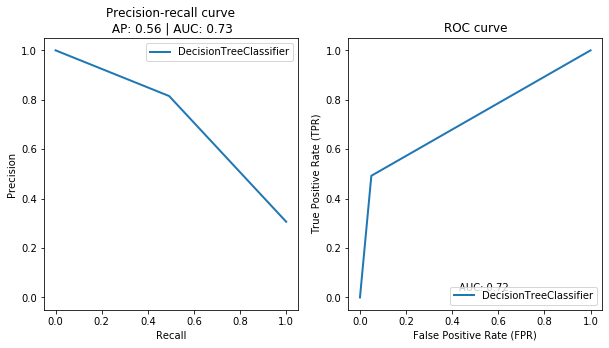

```python
dt = DecisionTreeClassifier(**clf.best_params_).fit(X_train, y_train)
y_pred = dt.predict(X_test)
print(dt.score(X_train, y_train))
print(accuracy_score(y_test, y_pred))
print(confusion_matrix(y_test, y_pred))
display_classification_report(y_test, y_pred)

_, axs = plt.subplots(1, 2,figsize=(10,5))
axs = axs.ravel()
plot_pr(y_test, y_pred, ax=axs[0], label="DecisionTreeClassifier")
plot_roc(y_test, y_pred, ax=axs[1], label="DecisionTreeClassifier")
```

#### CatBoost

```
0.8796680497925311
0.8211508553654744
[[420  26]
 [ 89 108]]
```

|  | precision | recall | f1-score | support |
| --- | --- | --- | --- | --- |
| 0 | 0.825147 | 0.941704 | 0.879581 | 446.000000 |
| 1 | 0.805970 | 0.548223 | 0.652568 | 197.000000 |
| accuracy | 0.821151 | 0.821151 | 0.821151 | 0.821151 |
| macro avg | 0.815559 | 0.744964 | 0.766075 | 643.000000 |
| weighted avg | 0.819272 | 0.821151 | 0.810030 | 643.000000 |

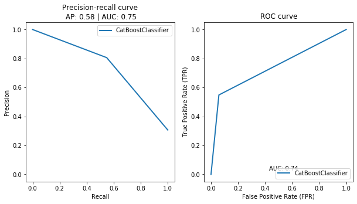

```python
cb = CatBoostClassifier(verbose=0, random_state=rnd_state).fit(X_train, y_train)
y_pred = cb.predict(X_test)
print(cb.score(X_train, y_train))
print(accuracy_score(y_test, y_pred))
print(confusion_matrix(y_test, y_pred))
display_classification_report(y_test, y_pred)

_, axs = plt.subplots(1, 2,figsize=(10,5))
axs = axs.ravel()
plot_pr(y_test, y_pred, ax=axs[0], label="CatBoostClassifier")
plot_roc(y_test, y_pred, ax=axs[1], label="CatBoostClassifier")
```

#### XGBoost

```python
xgb_clf = XGBClassifier().fit(X_train, y_train)
y_train_preds = xgb_clf.predict(X_train)
y_test_preds = xgb_clf.predict(X_test)
# Print F1 scores and Accuracy
print("Training F1 Micro Average: ", f1_score(y_train, y_train_preds, average = "micro"))
print("Test F1 Micro Average: ", f1_score(y_test, y_test_preds, average = "micro"))
print("Test Accuracy: ", accuracy_score(y_test, y_test_preds))
```

```
Training F1 Micro Average:  0.9673236514522822
Test F1 Micro Average:  0.8024883359253501
Test Accuracy:  0.80248833592535
```

```python
xgb_clf = XGBClassifier(tree_method = "exact", predictor = "cpu_predictor")

# Create parameter grid
parameters = {"learning_rate": [0.1, 0.01],
               "gamma" : [0.01, 0.3, 0.5, 1, 2],
               "max_depth": [7, 10, 16],
               "colsample_bytree": [0.3, 0.8],
               "subsample": [0.2, 0.5],
               "reg_alpha": [0, 0.5, 1],
               "reg_lambda": [1, 1.5, 2, 3, 4.5],
              "min_child_weight": [1, 3, 5, 7],
               "n_estimators": [100, 500]}

xgb_rscv = RandomizedSearchCV(xgb_clf, param_distributions = parameters, scoring = make_scorer(accuracy_score),
                             cv = 10, verbose = 0)

model_xgboost = xgb_rscv.fit(X, y)
```

```
0.845954356846473
0.8273716951788491
[[420  26]
 [ 85 112]]
```

|  | precision | recall | f1-score | support |
| --- | --- | --- | --- | --- |
| 0 | 0.831683 | 0.941704 | 0.883281 | 446.000000 |
| 1 | 0.811594 | 0.568528 | 0.668657 | 197.000000 |
| accuracy | 0.827372 | 0.827372 | 0.827372 | 0.827372 |
| macro avg | 0.821639 | 0.755116 | 0.775969 | 643.000000 |
| weighted avg | 0.825528 | 0.827372 | 0.817525 | 643.000000 |

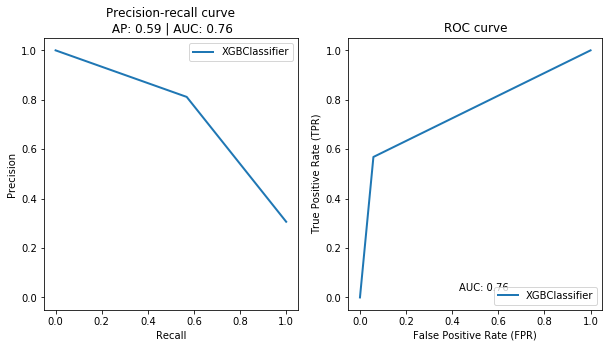

```python
clf = XGBClassifier(**model_xgboost.best_params_).fit(X_train, y_train)
y_pred = clf.predict(X_test)
print(clf.score(X_train, y_train))
print(accuracy_score(y_test, y_pred))
print(confusion_matrix(y_test, y_pred))
display_classification_report(y_test, y_pred)

_, axs = plt.subplots(1, 2,figsize=(10,5))
axs = axs.ravel()
plot_pr(y_test, y_pred, ax=axs[0], label="XGBClassifier")
plot_roc(y_test, y_pred, ax=axs[1], label="XGBClassifier")
```

```python
ros = RandomOverSampler(random_state = rnd_state)
X = df[features]
y = df[target]
X_resampled, y_resampled = ros.fit_resample(X, y)

new_df = pd.DataFrame(X_resampled, columns = features)
new_df[target] = y_resampled
new_df[target].value_counts()
```

```
1    2229
0    2229
Name: is_ultra, dtype: int64
```

```python
X_train, X_test, y_train, y_test = train_test_split(X, y, test_size=0.2,\
                                                    random_state=rnd_state, stratify = y)

X_train, X_val, y_train, y_val \
    = train_test_split(X_train, y_train, test_size=0.25, random_state=rnd_state)
```

```
0.8796680497925311
0.8195956454121306
[[419  27]
 [ 89 108]]
```

|  | precision | recall | f1-score | support |
| --- | --- | --- | --- | --- |
| 0 | 0.824803 | 0.939462 | 0.878407 | 446.000000 |
| 1 | 0.800000 | 0.548223 | 0.650602 | 197.000000 |
| accuracy | 0.819596 | 0.819596 | 0.819596 | 0.819596 |
| macro avg | 0.812402 | 0.743843 | 0.764505 | 643.000000 |
| weighted avg | 0.817204 | 0.819596 | 0.808613 | 643.000000 |

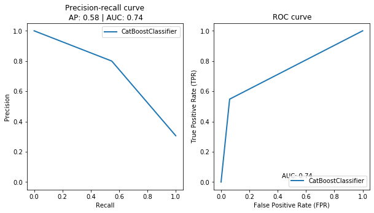

```python
cb = CatBoostClassifier(verbose=0, random_state=rnd_state).fit(X_train, y_train)
y_pred = cb.predict(X_test)
print(cb.score(X_train, y_train))
print(accuracy_score(y_test, y_pred))
print(confusion_matrix(y_test, y_pred))
display_classification_report(y_test, y_pred)

_, axs = plt.subplots(1, 2,figsize=(10,5))
axs = axs.ravel()
plot_pr(y_test, y_pred, ax=axs[0], label="CatBoostClassifier")
plot_roc(y_test, y_pred, ax=axs[1], label="CatBoostClassifier")
```